# ADHD management

## Meta-regression: Indirect comparison between combined vs(medication plus psychosocial) and medication

6 medication studies

0 combined studies

Not enough studies to compare medication and combined

## Meta-regression: Indirect comparison between combined vs(medication plus psychosocial) and psychosocial

0 psychosocial studies

0 combined studies

Not enough studies to compare psychosocial and combined

## MPH, AMPH, and NRI’s Section: Intervention: int_atomoxetine

## Intervention: int_atomoxetine

### Outcome: functional:continuous

No data #1.

## Intervention: int_atomoxetine

### Outcome: functional:categorical

Analyzing 0 studies.

No data.

## Intervention: int_atomoxetine

### Outcome: cognitive:continuous

No data #1.

## Intervention: int_atomoxetine

### Outcome: cognitive:categorical

Analyzing 0 studies.

No data.

## Intervention: int_atomoxetine

### Outcome: symptom:continuous

| ID | measure | mean_ctrl_cont | SD_ctrl_cont | n_ctrl_cont | mean_int_cont | SD_int_cont | n_int_cont | yi | se | study.design |
| --- | --- | --- | --- | --- | --- | --- | --- | --- | --- | --- |
| Sutherland, 2012{#1764} NS-NRI-ATX | AISRS (Adult ADHD Investigator Symptom Rating Scale) | 22.9 | 14.20 | 47 | 18.2 | 11.20 | 97 | -0.3815640 | 0.1791407 | RCT |
| Weisler, 2012{#1844} NS-NRI-ATX | ADHD-RS-IV (Attention-Deficit/Hyperactivity Disorder Rating Scale, Version IV) change from baseline | -8.8 | 11.74 | 73 | -15.3 | 14.52 | 73 | -0.4897293 | 0.1679840 | RCT |

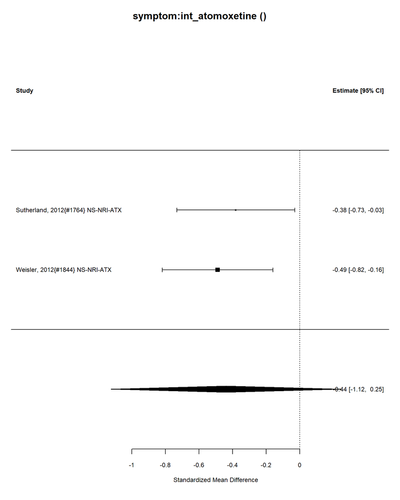

| estimate | conf.low | conf.high |
| --- | --- | --- |
| -0.44 | -1.12 | 0.25 |

Number of studies = 2

Intervention sample = 170

Control sample = 120

Total sample = 290.

I-squared = 0 %

Convert Effect Size to Real Units

Estimated effect in original units = -5.7.

## Intervention: int_atomoxetine

### Outcome: symptom:categorical

Analyzing 3 studies.

Analyzing 3 studies.

### Control Types

| control | n |
| --- | --- |
| Placebo | 2 |
| Waitlist | 1 |

| ID | measure | yi | se | study.design |
| --- | --- | --- | --- | --- |
| Sobanski, 2012{#1726} NS-NRI-ATX | Treatment response (30% or more reduction) | -3.25 | 1.41 | RCT |
| Upadhyaya, 2013{#8658} NS-NRI-ATX | CAARS-Inv:SV ≥30% reduction from baseline and CGI-ADHD-S ≤3 (minimally ill) | -0.25 | 0.08 | RCT |
| Young, 2011{#1899} NS-NRI-ATX | CAARS, response rate (≥25% reduction in CAARS Total ADHD Symptoms Score) | 0.49 | 0.09 | RCT |

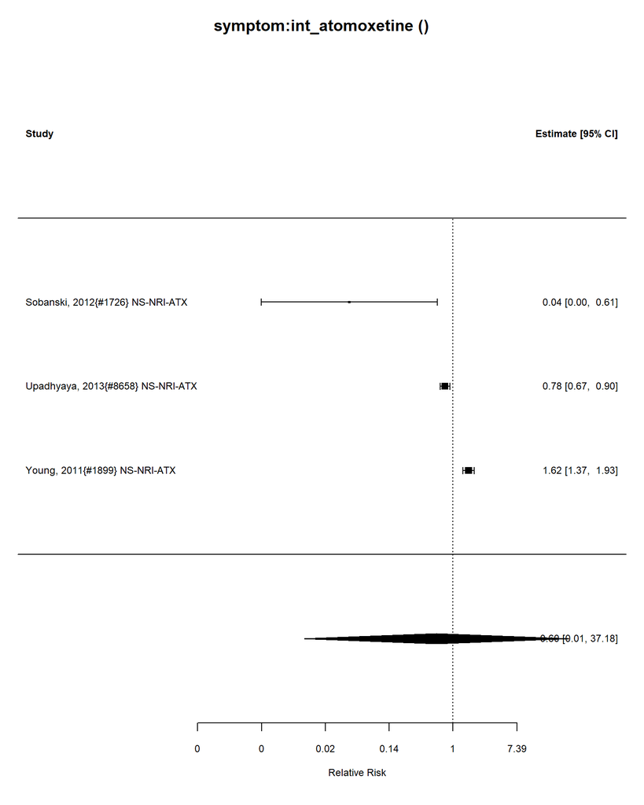

Number of studies = 3  
Intervention sample = 554  
Control sample = 513  
Total sample = 1067

### Relative Risk Estimate

|  | estimate | se | tval | df | pval | ci.lb | ci.ub |
| --- | --- | --- | --- | --- | --- | --- | --- |
| intrcpt | 0.5945205 | 2.611696 | 0.5827483 | 7.389056 | 1.896481 | 0.0095616 | 37.33757 |

I-squared = 99 %

##### Publication Bias Tests

###### Begg (non-parametric)

```
Rank Correlation Test for Funnel Plot Asymmetry

Kendall's tau = 0.3333, p = 1.0000
```

###### Egger (parametric)

```
Regression Test for Funnel Plot Asymmetry

Model:     mixed-effects meta-regression model
Predictor: standard error

Test for Funnel Plot Asymmetry: t = -2.1509, df = 1, p = 0.2771
Limit Estimate (as sei -> 0):   b =  0.3222 (CI: -4.9636, 5.6079)
```

###### Trim and Fill

Estimate and CIs

|  | estimate | ci.lb | ci.ub |
| --- | --- | --- | --- |
| intrcpt | 0.6 | 0.01 | 37.18 |

TrimFill Relative Risk Estimate: 1

###### int_stimulant vs int_nonstimulant meta-regression

### Meta-regression: stimulant vs non-stimulant

0 stimulant studies

3 nonstimulant studies

Not enough studies to compare stimulant and nonstimulant

### Meta-regression: AMPH vs MPH

### AMPH vs MPH meta-regression

0n AMPH studies

0 nMPH studies

Not enough studies to compare AMPH and MPH

## Meta-regression: Indirect comparison between combined vs(medication plus psychosocial) and medication

3 medication studies

0 combined studies

Not enough studies to compare medication and combined

## Meta-regression: Indirect comparison between combined vs(medication plus psychosocial) and psychosocial

0 psychosocial studies

0 combined studies

Not enough studies to compare psychosocial and combined

## Intervention: int_atomoxetine

### Outcome: substance_use:continuous

No data #1.

## Intervention: int_atomoxetine

### Outcome: substance_use:categorical

Analyzing 0 studies.

No data.

## Intervention: int_atomoxetine

### Outcome: relationship:continuous

No data #1.

## Intervention: int_atomoxetine

### Outcome: relationship:categorical

Analyzing 0 studies.

No data.

## Intervention: int_atomoxetine

### Outcome: BP:continuous

No data #1.

## Intervention: int_atomoxetine

### Outcome: BP:categorical

Analyzing 0 studies.

No data.

## Intervention: int_atomoxetine

### Outcome: sleep_disturbance:continuous

No data #1.

## Intervention: int_atomoxetine

### Outcome: sleep_disturbance:categorical

Analyzing 3 studies.

Analyzing 3 studies.

### Control Types

| control | n |
| --- | --- |
| Placebo | 3 |

| ID | measure | yi | se | study.design |
| --- | --- | --- | --- | --- |
| Boehringer Ingelheim, 2022{#16134} NS-NRI-ATX | Insomnia | 0.00 | 0.97 | RCT |
| Michelson, 2003{#1554} NS-NRI-ATX | Insomnia | 0.87 | 0.23 | RCT |
| Weisler, 2012{#1844} NS-NRI-ATX | Number of participants reporting insomnia | -1.11 | 1.14 | RCT |

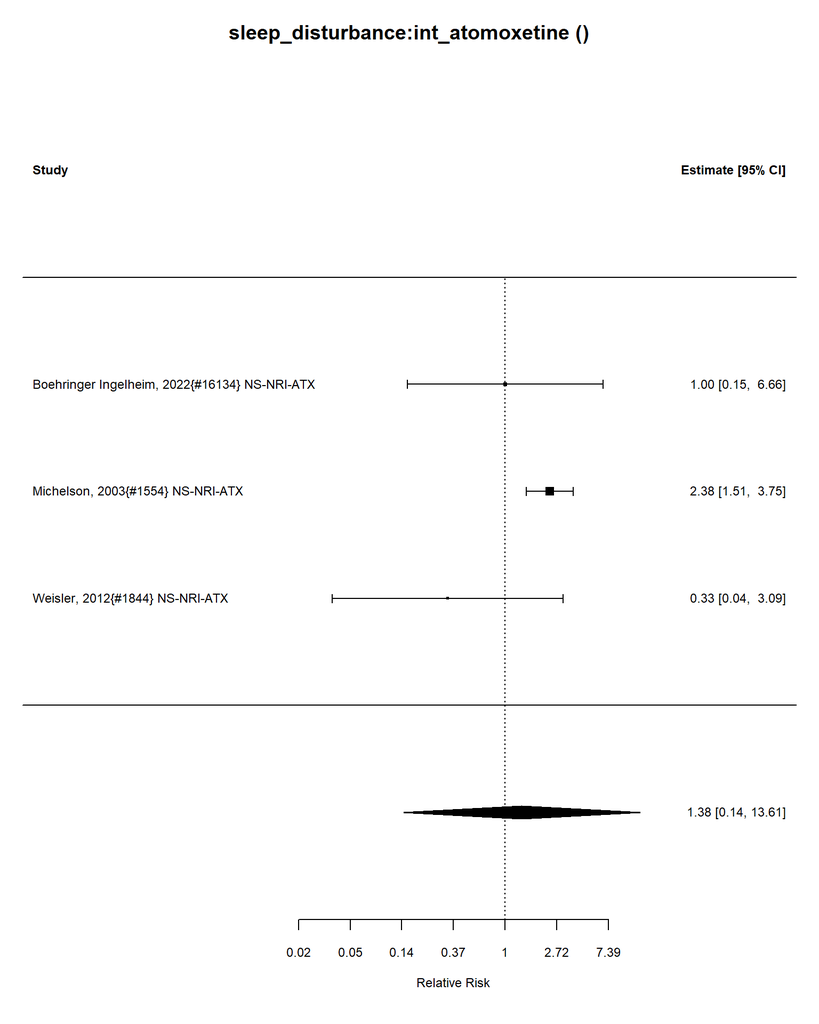

Number of studies = 3  
Intervention sample = 374  
Control sample = 367  
Total sample = 741

### Relative Risk Estimate

|  | estimate | se | tval | df | pval | ci.lb | ci.ub |
| --- | --- | --- | --- | --- | --- | --- | --- |
| intrcpt | 1.377128 | 1.698932 | 1.840431 | 7.389056 | 1.840431 | 0.1394569 | 13.59905 |

I-squared = 45 %

##### Publication Bias Tests

###### Begg (non-parametric)

```
Rank Correlation Test for Funnel Plot Asymmetry

Kendall's tau = -1.0000, p = 0.3333
```

###### Egger (parametric)

```
Regression Test for Funnel Plot Asymmetry

Model:     mixed-effects meta-regression model
Predictor: standard error

Test for Funnel Plot Asymmetry: t = -3.2818, df = 1, p = 0.1883
Limit Estimate (as sei -> 0):   b =  1.2671 (CI: -1.2635, 3.7977)
```

###### Trim and Fill

Estimate and CIs

|  | estimate | ci.lb | ci.ub |
| --- | --- | --- | --- |
| intrcpt | 2.38 | 0.96 | 5.92 |

TrimFill Relative Risk Estimate: 2

###### int_stimulant vs int_nonstimulant meta-regression

### Meta-regression: stimulant vs non-stimulant

1 stimulant studies

2 nonstimulant studies

Not enough studies to compare stimulant and nonstimulant

### Meta-regression: AMPH vs MPH

### AMPH vs MPH meta-regression

0n AMPH studies

1 nMPH studies

Not enough studies to compare AMPH and MPH

## Meta-regression: Indirect comparison between combined vs(medication plus psychosocial) and medication

3 medication studies

0 combined studies

Not enough studies to compare medication and combined

## Meta-regression: Indirect comparison between combined vs(medication plus psychosocial) and psychosocial

0 psychosocial studies

0 combined studies

Not enough studies to compare psychosocial and combined

## Intervention: int_atomoxetine

### Outcome: AEs:continuous

No data #1.

## Intervention: int_atomoxetine

### Outcome: AEs:categorical

Analyzing 12 studies.

Analyzing 12 studies.

### Control Types

| control | n |
| --- | --- |
| Placebo | 12 |

| ID | measure | yi | se | study.design |
| --- | --- | --- | --- | --- |
| Adler, 2008{#1063} NS-NRI-ATX | Number of participants dropped out due to adverse event | 1.87 | 0.59 | RCT |
| Adler, 2009{#1056} NS-NRI-ATX | Number of participants with any adverse event | 0.09 | 0.04 | RCT |
| Boehringer Ingelheim, 2022{#16134} NS-NRI-ATX | Treatment emergent adverse events | 0.11 | 0.11 | RCT |
| Goto, 2017{#1347} NS-NRI-ATX | Number of participants with at least one adverse event | 0.41 | 0.07 | RCT |
| Marchant, 2011{#10688} NS-NRI-ATX | Number of participants with adverse events | 1.37 | 0.63 | RCT |
| McRae-Clark, 2010{#1547} NS-NRI-ATX | Number of Patients with an adverse event | 0.17 | 0.11 | RCT |
| Michelson, 2003{#1554} NS-NRI-ATX | Number of participants with adverse events | 0.59 | 0.49 | RCT |
| Sutherland, 2012{#1764} NS-NRI-ATX | Number of withdrawals attributed to treatment-related adverse events | 0.04 | 0.42 | RCT |
| Upadhyaya, 2013{#8658} NS-NRI-ATX | Number of participants with at least one adverse event during the double-blind treatment phase | 0.02 | 0.09 | RCT |
| Wang, 2022{#1833} NS-NRI-ATX | Number of participants with adverse events | 1.61 | 1.53 | RCT |
| Weisler, 2012{#1844} NS-NRI-ATX | Number of participants reporting any adverse events | 0.35 | 0.11 | RCT |
| Young, 2011{#1899} NS-NRI-ATX | Number of participants experiencing at least one treatment-emergent adverse event | 0.13 | 0.04 | RCT |

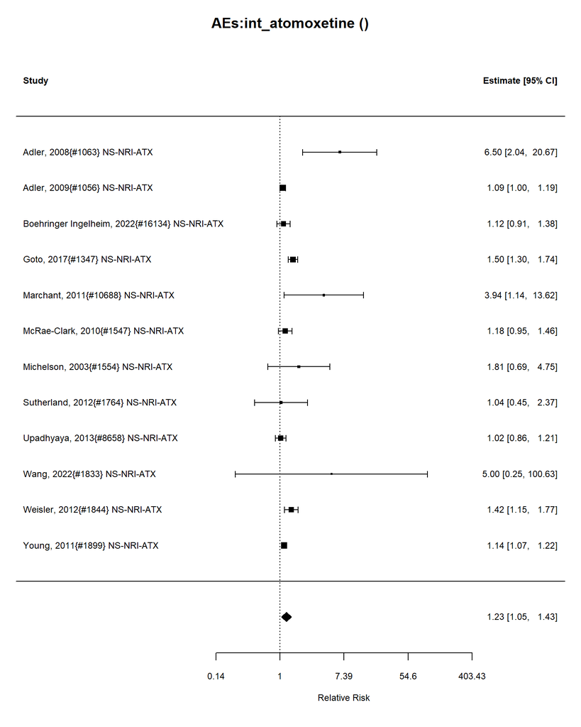

Number of studies = 12  
Intervention sample = 1735  
Control sample = 1509  
Total sample = 3244

### Relative Risk Estimate

|  | estimate | se | tval | df | pval | ci.lb | ci.ub |
| --- | --- | --- | --- | --- | --- | --- | --- |
| intrcpt | 1.221403 | 1.072508 | 17.99331 | 59874.14 | 1.01005 | 1.051271 | 1.433329 |

I-squared = 67 %

##### Publication Bias Tests

###### Begg (non-parametric)

```
Rank Correlation Test for Funnel Plot Asymmetry

Kendall's tau = 0.4545, p = 0.0447
```

###### Egger (parametric)

```
Regression Test for Funnel Plot Asymmetry

Model:     mixed-effects meta-regression model
Predictor: standard error

Test for Funnel Plot Asymmetry: t = 2.6605, df = 10, p = 0.0239
Limit Estimate (as sei -> 0):   b = 0.0683 (CI: -0.0933, 0.2299)
```

###### Trim and Fill

Estimate and CIs

|  | estimate | ci.lb | ci.ub |
| --- | --- | --- | --- |
| intrcpt | 1.2 | 1.07 | 1.34 |

TrimFill Relative Risk Estimate: 1

###### int_stimulant vs int_nonstimulant meta-regression

### Meta-regression: stimulant vs non-stimulant

1 stimulant studies

11 nonstimulant studies

Not enough studies to compare stimulant and nonstimulant

### Meta-regression: AMPH vs MPH

### AMPH vs MPH meta-regression

0n AMPH studies

1 nMPH studies

Not enough studies to compare AMPH and MPH

## Meta-regression: Indirect comparison between combined vs(medication plus psychosocial) and medication

12 medication studies

0 combined studies

Not enough studies to compare medication and combined

## Meta-regression: Indirect comparison between combined vs(medication plus psychosocial) and psychosocial

0 psychosocial studies

0 combined studies

Not enough studies to compare psychosocial and combined

## Intervention: int_atomoxetine

### Outcome: mortality:continuous

No data #1.

## Intervention: int_atomoxetine

### Outcome: mortality:categorical

Analyzing 7 studies.

Analyzing 7 studies.

### Control Types

| control | n |
| --- | --- |
| Placebo | 7 |

| ID | measure | yi | se | study.design |
| --- | --- | --- | --- | --- |
| Boehringer Ingelheim, 2022{#16134} NS-NRI-ATX | Deaths | 0.00 | 1.98 | RCT |
| Goto, 2017{#1347} NS-NRI-ATX | Number of deaths | -0.01 | 2.00 | RCT |
| Sutherland, 2012{#1764} NS-NRI-ATX | Number of deaths | 0.71 | 1.99 | RCT |
| Upadhyaya, 2013{#8658} NS-NRI-ATX | Number of deaths | 1.13 | 1.63 | RCT |
| Wang, 2022{#1833} NS-NRI-ATX | All-cause mortality | 0.00 | 1.99 | RCT |
| Weisler, 2012{#1844} NS-NRI-ATX | Number of deaths | 0.01 | 1.99 | RCT |
| Young, 2011{#1899} NS-NRI-ATX | Number of deaths | 0.13 | 2.00 | RCT |

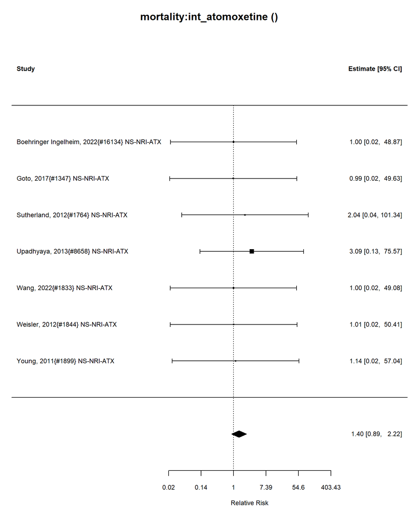

Number of studies = 7  
Intervention sample = 963  
Control sample = 874  
Total sample = 1837

### Relative Risk Estimate

|  | estimate | se | tval | df | pval | ci.lb | ci.ub |
| --- | --- | --- | --- | --- | --- | --- | --- |
| intrcpt | 1.404948 | 1.20925 | 6.049647 | 403.4288 | 1.127497 | 0.8869204 | 2.225541 |

I-squared = 0 %

##### Publication Bias Tests

###### Begg (non-parametric)

```
Rank Correlation Test for Funnel Plot Asymmetry

Kendall's tau = -0.1429, p = 0.7726
```

###### Egger (parametric)

```
Regression Test for Funnel Plot Asymmetry

Model:     mixed-effects meta-regression model
Predictor: standard error

Test for Funnel Plot Asymmetry: t = -3.7469, df = 5, p = 0.0133
Limit Estimate (as sei -> 0):   b =  5.5736 (CI: 1.9712, 9.1761)
```

###### Trim and Fill

Estimate and CIs

|  | estimate | ci.lb | ci.ub |
| --- | --- | --- | --- |
| intrcpt | 1.4 | 0.89 | 2.22 |

TrimFill Relative Risk Estimate: 1

###### int_stimulant vs int_nonstimulant meta-regression

### Meta-regression: stimulant vs non-stimulant

1 stimulant studies

6 nonstimulant studies

Not enough studies to compare stimulant and nonstimulant

### Meta-regression: AMPH vs MPH

### AMPH vs MPH meta-regression

0n AMPH studies

1 nMPH studies

Not enough studies to compare AMPH and MPH

## Meta-regression: Indirect comparison between combined vs(medication plus psychosocial) and medication

7 medication studies

0 combined studies

Not enough studies to compare medication and combined

## Meta-regression: Indirect comparison between combined vs(medication plus psychosocial) and psychosocial

0 psychosocial studies

0 combined studies

Not enough studies to compare psychosocial and combined

## Intervention: int_atomoxetine

### Outcome: behavior:continuous

No data #1.

## Intervention: int_atomoxetine

### Outcome: behavior:categorical

Analyzing 0 studies.

No data.

## Intervention: int_atomoxetine

### Outcome: appetite:continuous

No data #1.

## Intervention: int_atomoxetine

### Outcome: appetite:categorical

Analyzing 8 studies.

Analyzing 8 studies.

### Control Types

| control | n |
| --- | --- |
| Placebo | 8 |

| ID | measure | yi | se | study.design |
| --- | --- | --- | --- | --- |
| Adler, 2009{#1056} NS-NRI-ATX | Participants who experienced decreased appetite | -0.60 | 0.35 | RCT |
| Adler, 2009{#1061} NS-NRI-ATX | Decreased appetite | -1.51 | 0.41 | RCT |
| Boehringer Ingelheim, 2022{#16134} NS-NRI-ATX | Decreased apetite | -3.04 | 1.43 | RCT |
| Durell, 2013{#214} NS-NRI-ATX | Decreased appetite | -1.73 | 0.48 | RCT |
| Goto, 2017{#1347} NS-NRI-ATX | Decreased appetite adverse event | -3.12 | 0.72 | RCT |
| Upadhyaya, 2013{#8658} NS-NRI-ATX | Decreased appetite | 0.03 | 1.41 | RCT |
| Weisler, 2012{#1844} NS-NRI-ATX | Decreased appetite adverse event | -1.43 | 0.53 | RCT |
| Young, 2011{#1899} NS-NRI-ATX | Decreased appetite adverse event | -1.54 | 0.33 | RCT |

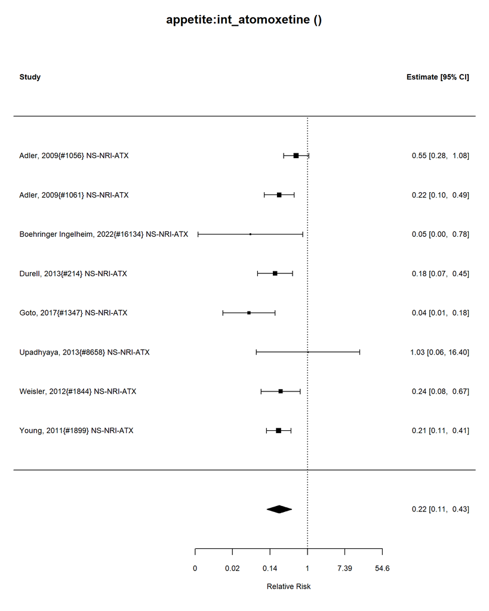

Number of studies = 8  
Intervention sample = 1473  
Control sample = 1447  
Total sample = 2920

### Relative Risk Estimate

|  | estimate | se | tval | df | pval | ci.lb | ci.ub |
| --- | --- | --- | --- | --- | --- | --- | --- |
| intrcpt | 0.22091 | 1.32313 | 0.0047009 | 1096.633 | 1 | 0.1130415 | 0.4317105 |

I-squared = 49 %

##### Publication Bias Tests

###### Begg (non-parametric)

```
Rank Correlation Test for Funnel Plot Asymmetry

Kendall's tau = -0.2143, p = 0.5484
```

###### Egger (parametric)

```
Regression Test for Funnel Plot Asymmetry

Model:     mixed-effects meta-regression model
Predictor: standard error

Test for Funnel Plot Asymmetry: t = -0.7918, df = 6, p = 0.4586
Limit Estimate (as sei -> 0):   b = -1.0579 (CI: -2.5765, 0.4608)
```

###### Trim and Fill

Estimate and CIs

|  | estimate | ci.lb | ci.ub |
| --- | --- | --- | --- |
| intrcpt | 0.28 | 0.15 | 0.52 |

TrimFill Relative Risk Estimate: 0

###### int_stimulant vs int_nonstimulant meta-regression

### Meta-regression: stimulant vs non-stimulant

1 stimulant studies

7 nonstimulant studies

Not enough studies to compare stimulant and nonstimulant

### Meta-regression: AMPH vs MPH

### AMPH vs MPH meta-regression

0n AMPH studies

1 nMPH studies

Not enough studies to compare AMPH and MPH

## Meta-regression: Indirect comparison between combined vs(medication plus psychosocial) and medication

8 medication studies

0 combined studies

Not enough studies to compare medication and combined

## Meta-regression: Indirect comparison between combined vs(medication plus psychosocial) and psychosocial

0 psychosocial studies

0 combined studies

Not enough studies to compare psychosocial and combined

## Intervention: int_atomoxetine

### Outcome: mood:continuous

No data #1.

## Intervention: int_atomoxetine

### Outcome: mood:categorical

Analyzing 5 studies.

Analyzing 5 studies.

### Control Types

| control | n |
| --- | --- |
| Placebo | 5 |

| ID | measure | yi | se | study.design |
| --- | --- | --- | --- | --- |
| Adler, 2009{#1056} NS-NRI-ATX | Irritability | 0.31 | 0.38 | RCT |
| Adler, 2009{#1061} NS-NRI-ATX | Irritability | -0.71 | 0.45 | RCT |
| Boehringer Ingelheim, 2022{#16134} NS-NRI-ATX | Irritability | -0.69 | 1.20 | RCT |
| Durell, 2013{#214} NS-NRI-ATX | Irritatibility | -1.15 | 0.57 | RCT |
| Young, 2011{#1899} NS-NRI-ATX | Irritability | -0.15 | 0.29 | RCT |

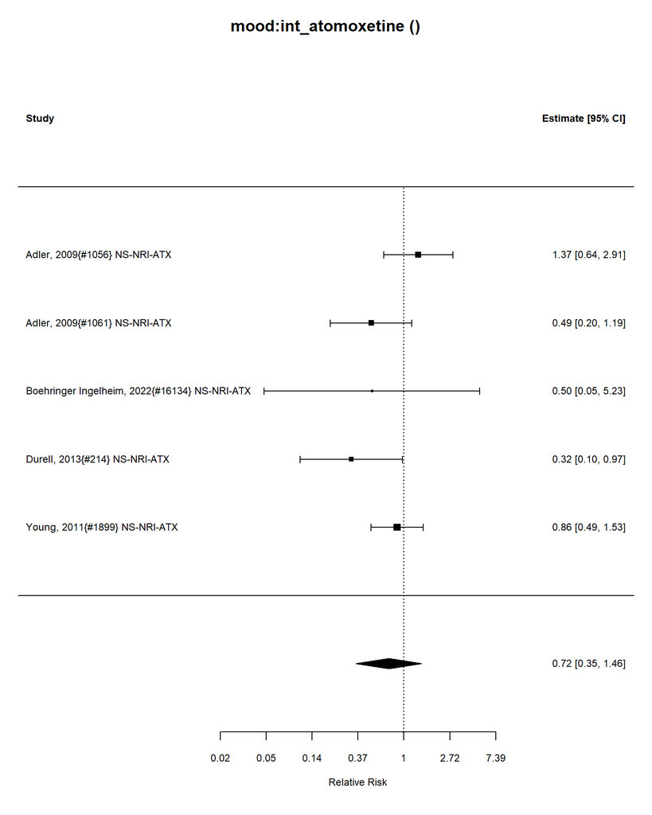

Number of studies = 5  
Intervention sample = 940  
Control sample = 921  
Total sample = 1861

### Relative Risk Estimate

|  | estimate | se | tval | df | pval | ci.lb | ci.ub |
| --- | --- | --- | --- | --- | --- | --- | --- |
| intrcpt | 0.7189237 | 1.284025 | 0.2725318 | 54.59815 | 1.29693 | 0.3534547 | 1.462285 |

I-squared = 39 %

##### Publication Bias Tests

###### Begg (non-parametric)

```
Rank Correlation Test for Funnel Plot Asymmetry

Kendall's tau = -0.4000, p = 0.4833
```

###### Egger (parametric)

```
Regression Test for Funnel Plot Asymmetry

Model:     mixed-effects meta-regression model
Predictor: standard error

Test for Funnel Plot Asymmetry: t = -1.0024, df = 3, p = 0.3900
Limit Estimate (as sei -> 0):   b =  0.2771 (CI: -1.7406, 2.2948)
```

###### Trim and Fill

Estimate and CIs

|  | estimate | ci.lb | ci.ub |
| --- | --- | --- | --- |
| intrcpt | 0.99 | 0.55 | 1.77 |

TrimFill Relative Risk Estimate: 1

###### int_stimulant vs int_nonstimulant meta-regression

### Meta-regression: stimulant vs non-stimulant

0 stimulant studies

5 nonstimulant studies

Not enough studies to compare stimulant and nonstimulant

### Meta-regression: AMPH vs MPH

### AMPH vs MPH meta-regression

0n AMPH studies

0 nMPH studies

Not enough studies to compare AMPH and MPH

## Meta-regression: Indirect comparison between combined vs(medication plus psychosocial) and medication

5 medication studies

0 combined studies

Not enough studies to compare medication and combined

## Meta-regression: Indirect comparison between combined vs(medication plus psychosocial) and psychosocial

0 psychosocial studies

0 combined studies

Not enough studies to compare psychosocial and combined

## MPH, AMPH, and NRI’s Section: Intervention: int_bupropion

## Intervention: int_bupropion

### Outcome: functional:continuous

No data #1.

## Intervention: int_bupropion

### Outcome: functional:categorical

Analyzing 0 studies.

No data.

## Intervention: int_bupropion

### Outcome: cognitive:continuous

No data #1.

## Intervention: int_bupropion

### Outcome: cognitive:categorical

Analyzing 0 studies.

No data.

## Intervention: int_bupropion

### Outcome: symptom:continuous

No data #1.

## Intervention: int_bupropion

### Outcome: symptom:categorical

Analyzing 3 studies.

Analyzing 3 studies.

### Control Types

| control | n |
| --- | --- |
| Placebo | 3 |

| ID | measure | yi | se | study.design |
| --- | --- | --- | --- | --- |
| Reimherr, 2005{#3108} | WRAADDS (Wender-Reimherr Adult Attention Deficit Disorder Scale), number with at least 50% reduction | 1.23 | 0.71 | RCT |
| Wilens, 2001{#1882} | DSM-IV ADHD symptom checklist, at least 30% improvement | -0.73 | 0.32 | RCT |
| Wilens, 2005{#1878} | ADHD-RS, at least a 30% reduction | -0.54 | 0.20 | RCT |

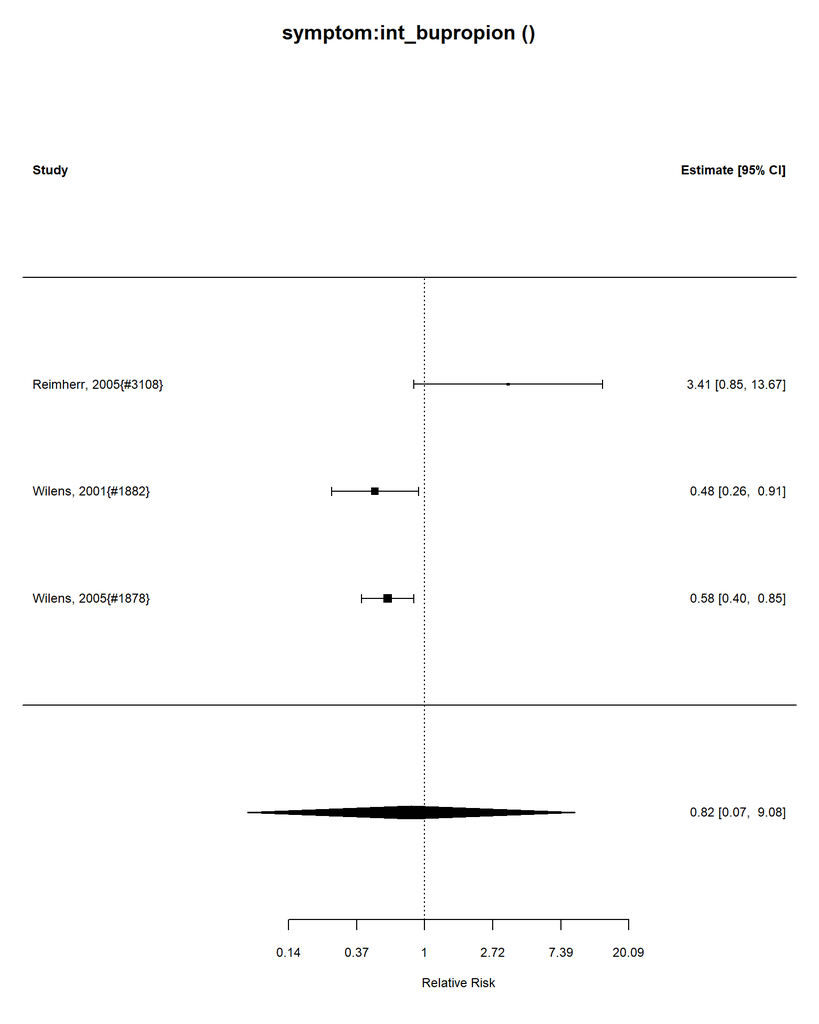

Number of studies = 3  
Intervention sample = 131  
Control sample = 118  
Total sample = 249

### Relative Risk Estimate

|  | estimate | se | tval | df | pval | ci.lb | ci.ub |
| --- | --- | --- | --- | --- | --- | --- | --- |
| intrcpt | 0.8187308 | 1.750673 | 0.7046881 | 7.389056 | 2.138276 | 0.0742736 | 9.115716 |

I-squared = 84 %

##### Publication Bias Tests

###### Begg (non-parametric)

```
Rank Correlation Test for Funnel Plot Asymmetry

Kendall's tau = 0.3333, p = 1.0000
```

###### Egger (parametric)

```
Regression Test for Funnel Plot Asymmetry

Model:     mixed-effects meta-regression model
Predictor: standard error

Test for Funnel Plot Asymmetry: t =  1.9045, df = 1, p = 0.3078
Limit Estimate (as sei -> 0):   b = -1.4264 (CI: -9.5029, 6.6501)
```

###### Trim and Fill

Estimate and CIs

|  | estimate | ci.lb | ci.ub |
| --- | --- | --- | --- |
| intrcpt | 0.82 | 0.07 | 9.08 |

TrimFill Relative Risk Estimate: 1

###### int_stimulant vs int_nonstimulant meta-regression

### Meta-regression: stimulant vs non-stimulant

0 stimulant studies

0 nonstimulant studies

Not enough studies to compare stimulant and nonstimulant

### Meta-regression: AMPH vs MPH

### AMPH vs MPH meta-regression

0n AMPH studies

0 nMPH studies

Not enough studies to compare AMPH and MPH

## Meta-regression: Indirect comparison between combined vs(medication plus psychosocial) and medication

0 medication studies

0 combined studies

Not enough studies to compare medication and combined

## Meta-regression: Indirect comparison between combined vs(medication plus psychosocial) and psychosocial

0 psychosocial studies

0 combined studies

Not enough studies to compare psychosocial and combined

## Intervention: int_bupropion

### Outcome: substance_use:continuous

No data #1.

## Intervention: int_bupropion

### Outcome: substance_use:categorical

Analyzing 0 studies.

No data.

## Intervention: int_bupropion

### Outcome: relationship:continuous

No data #1.

## Intervention: int_bupropion

### Outcome: relationship:categorical

Analyzing 0 studies.

No data.

## Intervention: int_bupropion

### Outcome: BP:continuous

No data #1.

## Intervention: int_bupropion

### Outcome: BP:categorical

Analyzing 0 studies.

No data.

## Intervention: int_bupropion

### Outcome: sleep_disturbance:continuous

No data #1.

## Intervention: int_bupropion

### Outcome: sleep_disturbance:categorical

Analyzing 1 studies.

Analyzing 1 studies.

### Control Types

| control | n |
| --- | --- |
| Placebo | 1 |

| ID | measure | yi | se | study.design |
| --- | --- | --- | --- | --- |
| Wilens, 2005{#1878} | Insomnia | 0.51 | 0.49 | RCT |

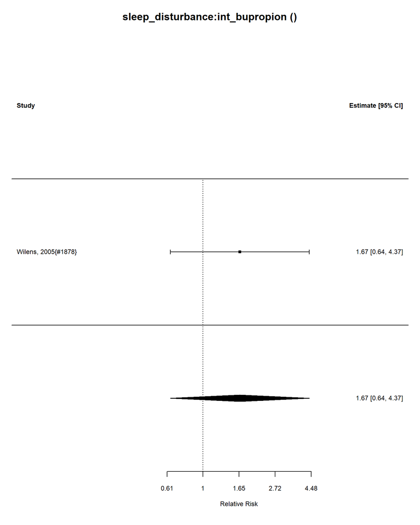

Number of studies = 1  
Intervention sample = 81  
Control sample = 81  
Total sample = 162

### Relative Risk Estimate

|  | estimate | se | zval | pval | ci.lb | ci.ub |
| --- | --- | --- | --- | --- | --- | --- |
| intrcpt | 1.665291 | 1.632316 | 2.829217 | 1.349859 | 0.6376282 | 4.349235 |

I-squared = 0 %

## Intervention: int_bupropion

### Outcome: AEs:continuous

No data #1.

## Intervention: int_bupropion

### Outcome: AEs:categorical

Analyzing 2 studies.

Analyzing 2 studies.

### Control Types

| control | n |
| --- | --- |
| Placebo | 2 |

| ID | measure | yi | se | study.design |
| --- | --- | --- | --- | --- |
| Wilens, 2001{#1882} | Number of participants with adverse events outcome | 0.14 | 0.25 | RCT |
| Wilens, 2005{#1878} | Number with any adverse event | 0.54 | 0.10 | RCT |

[figure not shown]

Number of studies = 2  
Intervention sample = 102  
Control sample = 100  
Total sample = 202

### Relative Risk Estimate

|  | estimate | se | tval | df | pval | ci.lb | ci.ub |
| --- | --- | --- | --- | --- | --- | --- | --- |
| intrcpt | 1.491825 | 1.20925 | 8.671138 | 2.718282 | 1.32313 | 0.1394569 | 16.11902 |

I-squared = 54 %

## Intervention: int_bupropion

### Outcome: mortality:continuous

No data #1.

## Intervention: int_bupropion

### Outcome: mortality:categorical

Analyzing 0 studies.

No data.

## Intervention: int_bupropion

### Outcome: behavior:continuous

No data #1.

## Intervention: int_bupropion

### Outcome: behavior:categorical

Analyzing 0 studies.

No data.

## Intervention: int_bupropion

### Outcome: appetite:continuous

No data #1.

## Intervention: int_bupropion

### Outcome: appetite:categorical

Analyzing 0 studies.

No data.

## Intervention: int_bupropion

### Outcome: mood:continuous

No data #1.

## Intervention: int_bupropion

### Outcome: mood:categorical

Analyzing 1 studies.

Analyzing 1 studies.

### Control Types

| control | n |
| --- | --- |
| Placebo | 1 |

| ID | measure | yi | se | study.design |
| --- | --- | --- | --- | --- |
| Wilens, 2005{#1878} | Irritability | -0.92 | 0.82 | RCT |

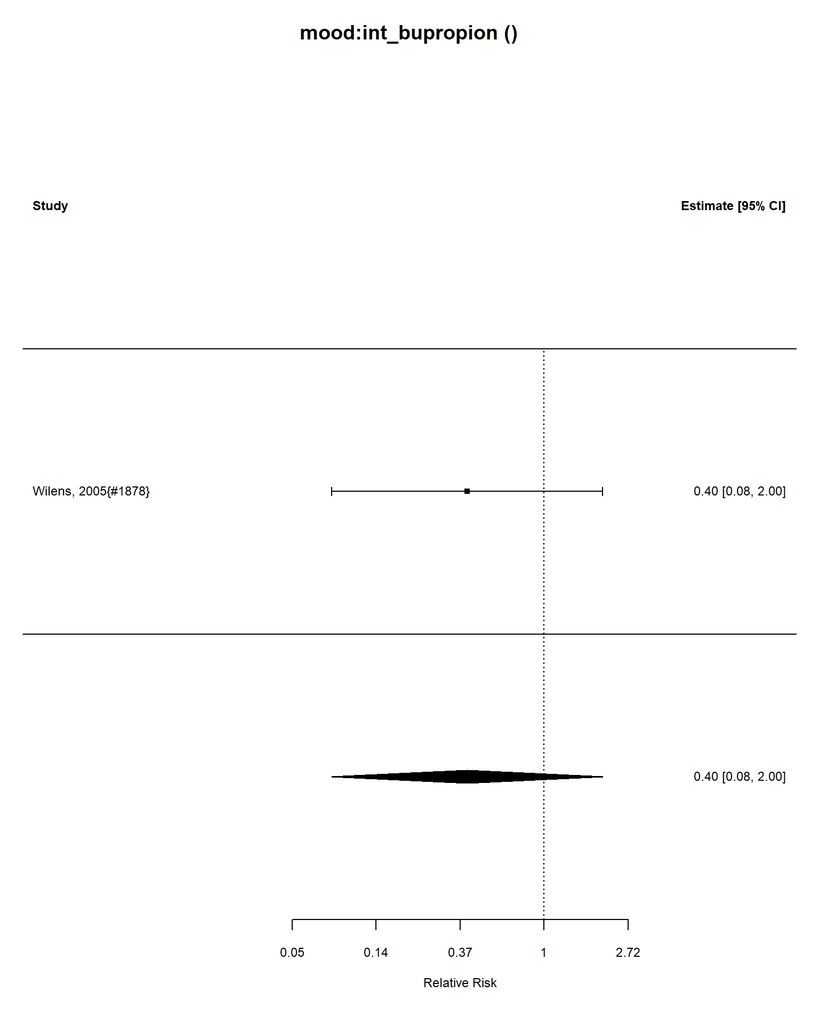

Number of studies = 1  
Intervention sample = 81  
Control sample = 81  
Total sample = 162

### Relative Risk Estimate

|  | estimate | se | zval | pval | ci.lb | ci.ub |
| --- | --- | --- | --- | --- | --- | --- |
| intrcpt | 0.398519 | 2.2705 | 0.3262798 | 1.29693 | 0.079659 | 1.993715 |

I-squared = 0 %

## Intervention: int_CBT_only

### Outcome: functional:continuous

| ID | measure | mean_ctrl_cont | SD_ctrl_cont | n_ctrl_cont | mean_int_cont | SD_int_cont | n_int_cont | yi | se | study.design |
| --- | --- | --- | --- | --- | --- | --- | --- | --- | --- | --- |
| Nasri, 2023{#2954} CBT | SDS (Sheehan Disability Scale) | 15 | 8.16 | 31 | 14 | 7.65 | 30 | -0.1247531 | 0.2563571 | RCT |

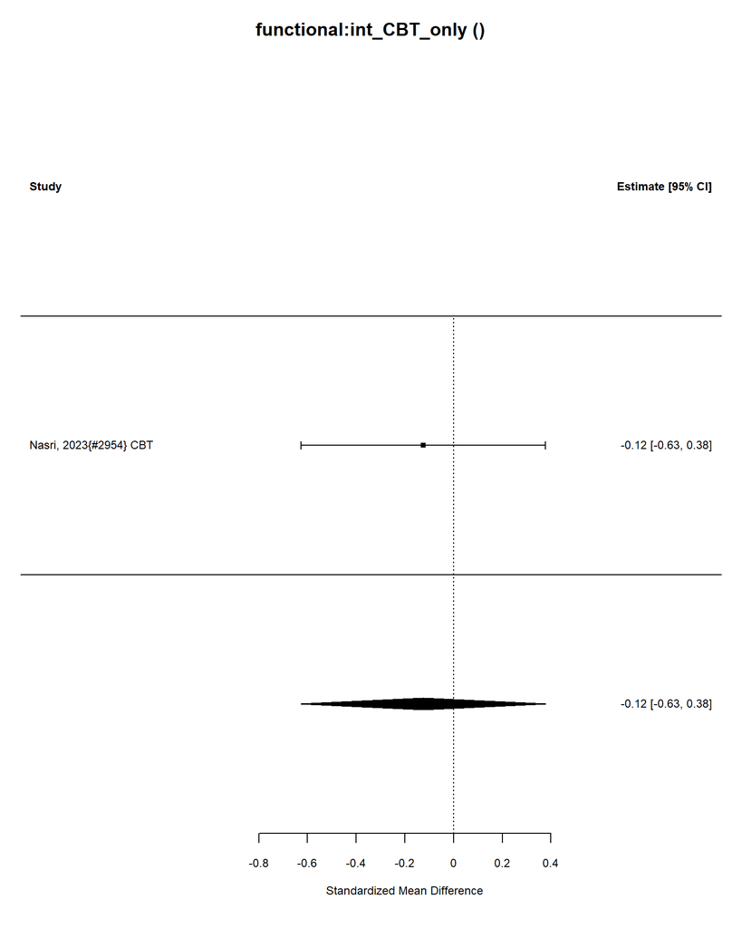

| estimate | conf.low | conf.high |
| --- | --- | --- |
| -0.12 | -0.63 | 0.38 |

Number of studies = 1

Intervention sample = 30

Control sample = 31

Total sample = 61.

I-squared = 0 %

Convert Effect Size to Real Units

Estimated effect in original units = -1.02.

## Intervention: int_CBT_only

### Outcome: functional:categorical

Analyzing 0 studies.

No data.

## Intervention: int_CBT_only

### Outcome: cognitive:continuous

| ID | measure | mean_ctrl_cont | SD_ctrl_cont | n_ctrl_cont | mean_int_cont | SD_int_cont | n_int_cont | yi | se | study.design |
| --- | --- | --- | --- | --- | --- | --- | --- | --- | --- | --- |
| Virta, 2010{#3410} CBT | CNSVS ( Central Nervous System Vital Signs computerized neurocognitive test battery) neurocognitive index | 102.5 | 10.1 | 10 | 97.6 | 9.2 | 10 | -0.4857382 | 0.4537604 | RCT |

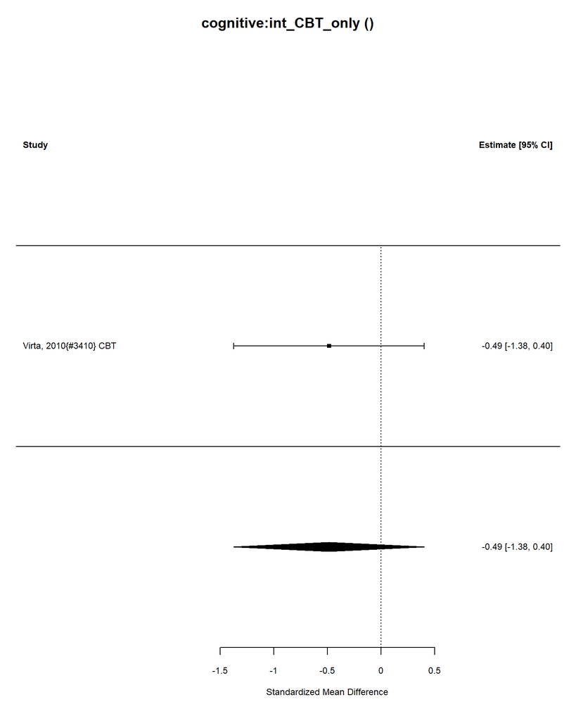

| estimate | conf.low | conf.high |
| --- | --- | --- |
| -0.49 | -1.38 | 0.4 |

Number of studies = 1

Intervention sample = 10

Control sample = 10

Total sample = 20.

I-squared = 0 %

Convert Effect Size to Real Units

Estimated effect in original units = -4.91.

## Intervention: int_CBT_only

### Outcome: cognitive:categorical

Analyzing 0 studies.

No data.

## Intervention: int_CBT_only

### Outcome: symptom:continuous

| ID | measure | mean_ctrl_cont | SD_ctrl_cont | n_ctrl_cont | mean_int_cont | SD_int_cont | n_int_cont | yi | se | study.design |
| --- | --- | --- | --- | --- | --- | --- | --- | --- | --- | --- |
| Nasri, 2023{#2954} CBT | ASRS-v1.1 (Adult ADHD Self-Report Scale version 1.1) | 47.4 | 9.02 | 31 | 40.5 | 10.5 | 36 | -0.6927675 | 0.2522249 | RCT |
| Virta, 2010{#3410} CBT | BADDS (Brown Attention Deficit Disorder Scale – Adult Version) | 70.0 | 14.20 | 10 | 71.5 | 18.6 | 10 | 0.0868120 | 0.4474242 | RCT |
| Virta, 2010{#8307} CBT | BADDS (Brown Attention deficit disorder Scale – adult version) | 70.0 | 14.20 | 7 | 71.9 | 18.4 | 9 | 0.1073573 | 0.5043099 | RCT |

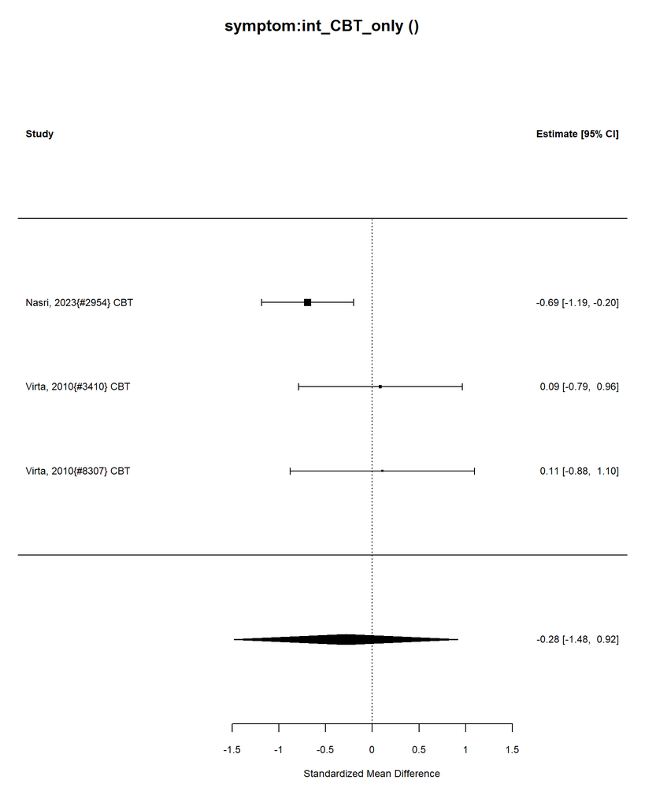

| estimate | conf.low | conf.high |
| --- | --- | --- |
| -0.28 | -1.48 | 0.92 |

Number of studies = 3

Intervention sample = 55

Control sample = 48

Total sample = 103.

I-squared = 45 %

Convert Effect Size to Real Units

Estimated effect in original units = -3.52.

##### Publication Bias Tests

###### Begg (non-parametric)

Rank Correlation Test for Funnel Plot Asymmetry Kendall’s tau = 0.3333, p = 1.0000

###### Egger (parametric)

Regression Test for Funnel Plot Asymmetry

Model: mixed-effects meta-regression model Predictor: standard error

Test for Funnel Plot Asymmetry: t = 6.9454, df = 1, p = 0.0910 Limit Estimate (as sei -> 0): b = -1.5690 (CI: -3.8027, 0.6647)

###### Trim and Fill

Estimate and Cis

|  | estimate | ci.lb | ci.ub |
| --- | --- | --- | --- |
| intrcpt | -0.28 | -1.48 | 0.92 |

### Meta-regression: stimulant vs non-stimulant

0 stimulant studies

0 nonstimulant studies

Not enough studies to compare stimulant and nonstimulant

### Meta-regression: AMPH vs MPH

### AMPH vs MPH meta-regression

0n AMPH studies

0 nMPH studies

Not enough studies to compare AMPH and MPH

## Meta-regression: Indirect comparison between combined vs(medication plus psychosocial) and medication

0 medication studies

0 combined studies

Not enough studies to compare medication and combined

## Meta-regression: Indirect comparison between combined vs(medication plus psychosocial) and psychosocial

3 psychosocial studies

0 combined studies

Not enough studies to compare psychosocial and combined